# Tumor Evolution Analysis in LUAD (Sherlock-Lung)

Tongwu Zhang

2025-08-05

## 1 Overview

This R Markdown document reproduces the main analyses and figures for tumor evolution in high-clonality LUAD (Lung Adenocarcinoma) dataset from the Sherlock-Lung study

manuscript title: Deciphering lung adenocarcinoma evolution and the role of LINE-1 retrotransposition

Fig. 6: ZNF695 upregulation in tumors and its association with mutational signature ID2.

## 2 Load Required Libraries and Set Plotting Styles

(You may need to install some packages if missing)

```r
library(tidyverse)
library(ggplot2)
library(ggsankey)
library(scales)
library(hrbrthemes)   # For theme_ipsum_rc
library(cowplot)
library(forcats)
library(ggrepel)
library(ggnewscale)
library(data.table)
library(ggasym)
library(ggpmisc)
library(broom)
library(ggsci)
library(ggpubr)

# --- Define Helper Functions (if any custom) -----------------------------------
# Please source your custom functions here if needed, or place them in ./functions/
# source('./functions/your_custom_functions.R')

# --- Load Input Datasets ------------------------------------------------------
# All data files should be placed in the appropriate subfolders.
# Example folder structure:
#   ./data/           - for main input files
#   ./functions/      - for custom R functions
#   ./output/         - for saving plots and results

# Replace the filenames below with your actual dataset filenames.
# load Sherlock-lung data -------------------------------------------------
load('./data/BBsolution_final3_short.RData',verbose = T)
```

```
## Loading objects:
##   BBsolution
##   BBsolution4
##   hq_samples
##   wgs_groups_info
##   wgs_groups_info2
```

```r
load('./data/covdata0.RData',verbose = T)
```

```
## Loading objects:
##   covdata0
```

```r
load('./data/sherlock_data_all.RData',verbose = T)
```

```
## Loading objects:
##   sherlock_data
##   sherlock_data_full
##   sherlock_overall
##   sherlock_type_colors
##   sherlock_freq
##   sherlock_freq_hq
```

```r
load('./data/sherlock_variable.RData',verbose = T)
```

```
## Loading objects:
##   sherlock_variable
```

```r
load('./data/sp_group_data.RData',verbose = T)
```

```
## Loading objects:
##   sp_group_color
##   sp_group_color_new
##   sp_group_data
##   sp_group_data2
```

```r
load('./data/id2data.RData',verbose = T)
```

```
## Loading objects:
##   id2data
##   id2color
```

```r
load('./data/tedata.RData',verbose = T)
```

```
## Loading objects:
##   tedata
```

```r
load('./data/annotable_ens90.RData',verbose = T)
```

```
## Loading objects:
##   grch37
##   grch38
##   grch37_gt
##   grch38_gt
```

```r
protein_coding_genes <- grch38 %>% filter(biotype=='protein_coding') %>% pull(symbol) %>% unique()

# load function -----------------------------------------------------------
load('./data/ZTW_functions.RData')

# load analysis related data set
load('./data/kzfp_genes.RData')
load('./data/RNASeq_Exp.RData',verbose = T)
```

```
## Loading objects:
##   cdata3
##   rdata1
##   adata
```

```r
# --- Subset to LUAD Only ------------------------------------------------------
# Filter to high-quality LUAD samples only
hq_samples2 <- covdata0 %>%
  filter(Histology == 'Adenocarcinoma', Tumor_Barcode %in% hq_samples) %>%
  pull(Tumor_Barcode)
rm(list = c('hq_samples'))


id2data <- id2data %>% filter(Tumor_Barcode %in% hq_samples2)
tedata <- tedata %>% filter(Tumor_Barcode %in% hq_samples2)
rdata1 <- rdata1 %>% filter(Tumor_Barcode %in% hq_samples2, Gene %in% kzfp_genes,Gene %in% protein_coding_genes)
```

## 3 Fig. 6a: Expression difference of KZFP protein coding genes between IDs Present and Absent in tumors.

Analysis of differentially expressed KZFP protein coding genes between tumors with ID2 signatures and those without. Horizontal dashed lines represent significance thresholds (FDR < 0.05 in orange and FDR < 0.01 in red). The top 20 significant genes are annotated with gene names.

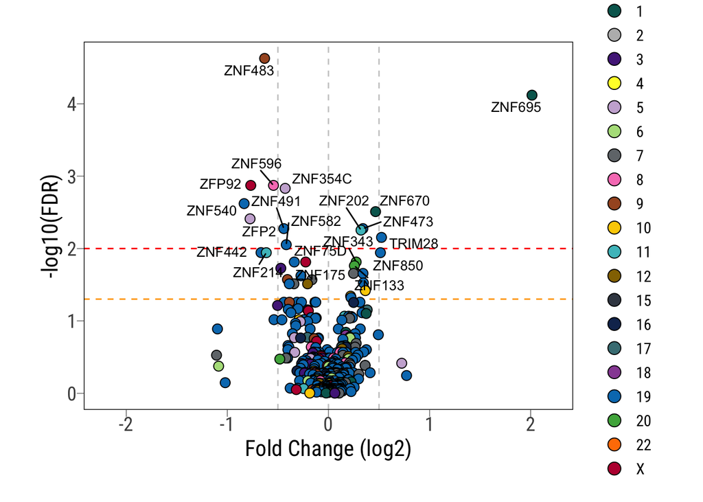

```r
rdata1 <- rdata1 %>% left_join(id2data %>% select(Tumor_Barcode,ID2,ID2_Present)) %>% filter(!is.na(ID2_Present))
rdata1 <- rdata1 %>%
  left_join(
    sherlock_data_full %>% filter(Gene == 'TP53', Type=='Mutation_Driver') %>% select(Tumor_Barcode,TP53=Alteration)
  ) %>%
  left_join(
    sherlock_data_full %>% filter(Gene == 'KRAS', Type=='Mutation_Driver') %>% select(Tumor_Barcode,KRAS=Alteration)
  ) %>%
  left_join(
    sherlock_data_full %>% filter(Gene == 'EGFR', Type=='Mutation_Driver') %>% select(Tumor_Barcode,EGFR=Alteration)
  )

rdata1 <- rdata1 %>% left_join(covdata0 %>% select(Tumor_Barcode,Smoking,Gender,Age))

fcdata <- rdata1 %>%
  filter(RNAseq_Type == 'Tumor') %>%
  group_by(Gene,ID2_Present) %>%
  summarise(Exp=median(Exp)) %>%
  ungroup() %>%
  pivot_wider(names_from = ID2_Present,values_from = Exp) %>%
  mutate(FC=log2(2^(Present)/(2^`Absent`)))

## Wilcox test ##
# tresult <- rdata1 %>%
#   filter(RNAseq_Type == 'Tumor') %>%
#   group_by(Gene) %>%
#   do(tidy(wilcox.test(Exp~ID2_Present, data=.))) %>%
#   ungroup() %>%
#   arrange(p.value) %>%
#   select(-method,-alternative) %>%
#   mutate(FDR=p.adjust(p.value,method="BH")) %>%
#   left_join(fcdata) %>%
#   left_join(kzfp %>% select(Gene=Label,chrom))

## logistic regression using glm
tresult <- rdata1 %>%
  filter(RNAseq_Type == 'Tumor') %>%
  mutate(ID2_Present=as.factor(ID2_Present)) %>%
  group_by(Gene) %>%
  do(tidy(glm(ID2_Present ~ Exp + Smoking + Age + Gender + TP53 + KRAS + EGFR, family='binomial',data=.,),conf.int = TRUE, conf.level = 0.95)) %>%
  filter(term=='Exp') %>%
  ungroup() %>%
  arrange(p.value) %>%
  mutate(FDR=p.adjust(p.value,method="BH")) %>%
  left_join(fcdata) %>%
  left_join(kzfp %>% select(Gene=Label,chrom))

tresult %>%
  ggplot(aes(FC,-log10(FDR),fill=chrom))+
  geom_vline(xintercept = c(-0.5,0,0.5),linetype=2,col='#cccccc')+
  geom_hline(yintercept = -log10(0.01),linetype=2,col='red',size=0.5)+
  geom_hline(yintercept = -log10(0.05),linetype=2,col='orange',size=0.5)+
  geom_point(pch=21,stroke=0.5,col='black',size=3)+
  scale_x_continuous(breaks = pretty_breaks(),limits = c(-2.2,2.2))+
  scale_y_continuous(breaks = pretty_breaks(n=7))+
  scale_fill_manual(values = rev(ncicolpal))+
  ggrepel::geom_text_repel(data=tresult %>% slice(1:20), aes(label=Gene),force = 10,size=3.5)+
  #ggrepel::geom_text_repel(data=tresult %>%filter(Gene %in% targets), aes(label=Gene),force = 10,size=4,col='red')+
  labs(x='Fold Change (log2)',y='-log10(FDR)')+
  guides(fill = guide_legend(override.aes = list(size=4)))+
  theme_ipsum_rc(base_size = 14,axis_title_just = 'm',axis_title_size = 16,grid=FALSE,ticks = T)+
  panel_border(color = 'black',size = 0.5)
```

```r
#ggsave(filename = 'KZFPs_DEGs_tumor_ID2_present_absent.pdf',width = 7,height = 6,device = cairo_pdf)
#ggsave(filename = './output/KZFPs_DEGs_tumor_ID2_present_absent_multivariable.pdf',width = 7,height = 6,device = cairo_pdf)
```

## 4 Fig. 6b: ZNF695 expression difference among ID2 present and absent group

Box plots illustrate the differential expression of ZNF695 among normal tissue or blood, tumors without ID2 signatures, and tumors with ID2 signatures.

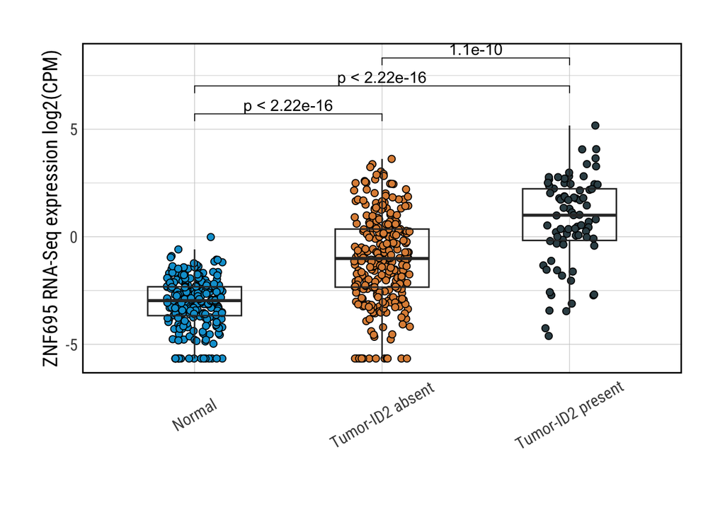

```r
my_comparisons <- list(c("Normal", "Tumor-ID2 absent"),c("Normal", "Tumor-ID2 present"),c("Tumor-ID2 absent", "Tumor-ID2 present"))

rdata1 %>%
  mutate(Group=if_else(RNAseq_Type == 'Normal','Normal',if_else(ID2_Present == 'Present','Tumor-ID2 present','Tumor-ID2 absent'))) %>%
  filter(Gene=='ZNF695') %>%
  ggplot(aes(Group,Exp))+
  geom_point(aes(fill=Group),pch=21,size=2,position = position_jitter(width = 0.15,height = 0),color="black")+
  geom_boxplot(width=0.5,outlier.shape = NA,alpha =0.25,fill=NA)+
  scale_fill_manual(values = pal_jama()(3)[3:1])+
  theme_ipsum_rc(axis_title_just = 'm',axis_title_size = 14)+
  theme(axis.text.x = element_text(angle = 30,hjust = 0.5,vjust = 0.5))+
  labs(x = "", y = 'ZNF695 RNA-Seq expression log2(CPM)')+
  guides(fill="none")+
  panel_border(color = 'black',linetype = 1)+
  stat_compare_means(comparisons = my_comparisons)
```

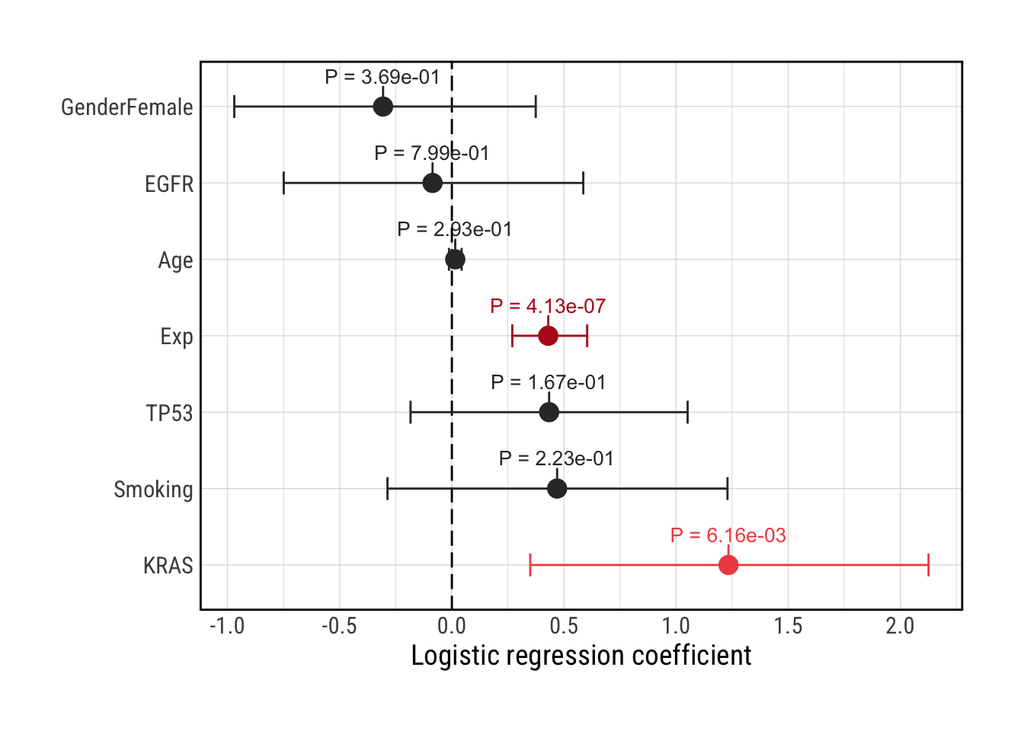

```r
#ggsave(filename = './output/KZFPs_DEGs_tumor_ID2_present_absent_example.pdf',width = 4,height = 7,device = cairo_pdf)

# adjusted for the cofounders e.g, smoking status, TP53, KRAS mutant status
tmpresult <- rdata1 %>%
  mutate(Smoking=if_else(Smoking == 'Unknown',NA_character_,Smoking)) %>%
  filter(Gene=='ZNF695',RNAseq_Type == 'Tumor') %>%
  mutate(ID2_Present=as.factor(ID2_Present)) %>%
  do(tidy(glm(ID2_Present ~ Exp + Smoking + Age + Gender + TP53 + KRAS + EGFR, family='binomial',data=.,),conf.int = TRUE, conf.level = 0.95)) %>%
  filter(term!='(Intercept)') %>%
  ungroup() %>%
  arrange(desc(estimate)) %>%
  #mutate(term=str_remove(term,"EGFR")) %>%
  mutate(term=str_remove(term,"Smoker")) %>%
  mutate(term=str_remove(term,"Yes")) %>%
  mutate(label=paste0('P = ',scientific_format(digits = 3)(p.value)))


tmpresult %>%
  mutate(p.value2 = if_else(p.value>0.05,NA,-log10(p.value))) %>%
  #mutate(conf.high = if_else(conf.high>10,NA,conf.high)) %>%
  #mutate(term=factor(term,levels=tmplevels,labels=tmplables)) %>%
  mutate(term=fct_inorder(term)) %>%
  ggplot(aes(estimate, term, xmin = conf.low, xmax = conf.high, height = 0,color=p.value2)) +
  geom_vline(xintercept = 0, lty = 5) +
  geom_errorbarh(height = .3)+
  geom_point(pch=19,size=4) +
  #scale_color_manual(values = c("FALSE"='black',"TRUE"='red'))+
  scale_color_gradient(low = "#EE5250FF",high = "#B71B1BFF",na.value = 'gray20')+
  ggrepel::geom_text_repel(aes(label=label),size=3.5,nudge_y = 0.4)+
  #facet_grid(~SP_Group_New)+
  theme_ipsum_rc(axis_title_just = 'm',axis_title_size = 14,grid_col = 'gray85')+
  theme(panel.spacing = unit(0.2,"cm"))+
  labs(x = "Logistic regression coefficient", y = NULL)+
  guides(color="none")+
  scale_x_continuous(breaks = pretty_breaks())+
  panel_border(color = 'black',linetype = 1)
```

```r
#ggsave(filename = './output/KZFPs_DEGs_tumor_ID2_present_absent_example2.pdf',width = 6,height = 4,device = cairo_pdf)
```

## 5 Fig. 6c: Correlation with ID2

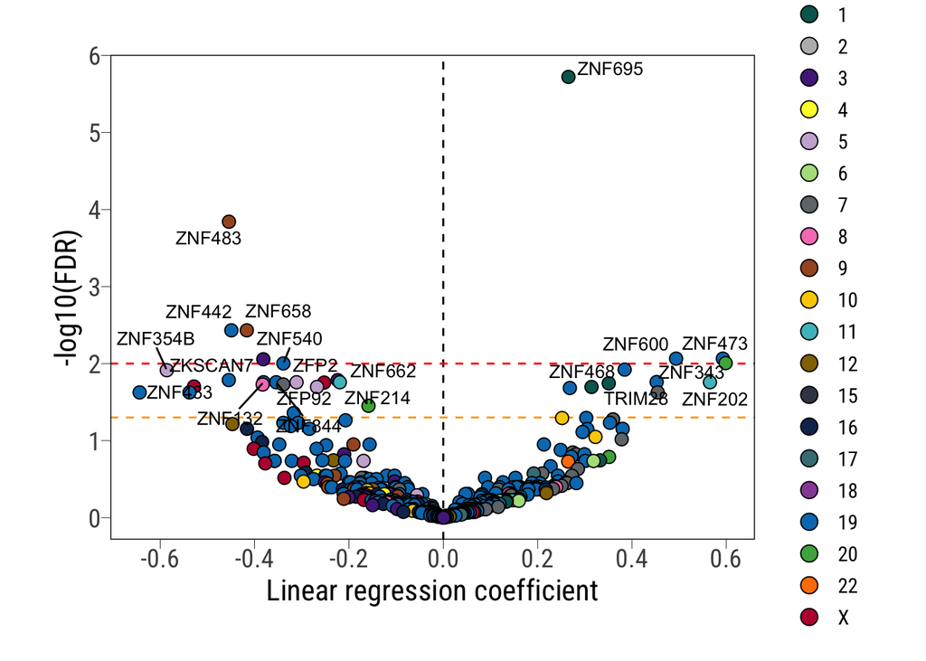

```r
# pearson correlation
# tresult <- rdata1 %>%
#   filter(RNAseq_Type == 'Tumor') %>%
#   left_join(id2data %>% select(Tumor_Barcode,ID2)) %>%
#   filter(ID2>0) %>%
#   group_by(Gene) %>%
#   do(tidy(cor.test(.$Exp,log2(.$ID2+1)))) %>%
#   ungroup() %>%
#   arrange(p.value) %>%
#   select(-method,-alternative) %>%
#   mutate(FDR=p.adjust(p.value,method="BH")) %>%
#   left_join(kzfp %>% select(Gene=Label,chrom))

# adjust for the covariables
tresult <- rdata1 %>%
  filter(RNAseq_Type == 'Tumor') %>%
  filter(ID2>0) %>%
  group_by(Gene) %>%
  do(tidy(lm(log2(ID2) ~ Exp + Smoking + Age + Gender + TP53 + KRAS + EGFR, data=.,),conf.int = TRUE, conf.level = 0.95)) %>%
  #do(tidy(cor.test(.$Exp,log2(.$ID2+1)))) %>%
  ungroup() %>%
  filter(term=='Exp') %>%
  arrange(p.value) %>%
  mutate(FDR=p.adjust(p.value,method="BH")) %>%
  left_join(kzfp %>% select(Gene=Label,chrom))


tresult %>%
  ggplot(aes(estimate,-log10(FDR),fill=chrom))+
  geom_vline(xintercept = 0,linetype=2)+
  geom_hline(yintercept = -log10(0.01),linetype=2,col='red',size=0.5)+
  geom_hline(yintercept = -log10(0.05),linetype=2,col='orange',size=0.5)+
  geom_point(pch=21,stroke=0.5,col='black',size=3)+
  scale_x_continuous(breaks = pretty_breaks())+
  scale_y_continuous(breaks = pretty_breaks(n = 7))+
  scale_fill_manual(values = rev(ncicolpal))+
  ggrepel::geom_text_repel(data=tresult %>% slice(1:20), aes(label=Gene),force = 10,size=3.5)+
  #ggrepel::geom_text_repel(data=tresult %>%filter(Gene %in% targets), aes(label=Gene),force = 10,size=4,col='red')+
  labs(x="Linear regression coefficient",y='-log10(FDR)')+
  guides(fill = guide_legend(override.aes = list(size=4)))+
  theme_ipsum_rc(base_size = 14,axis_title_just = 'm',axis_title_size = 16,grid=FALSE,ticks = T)+
  panel_border(color = 'black',size = 0.5)
```

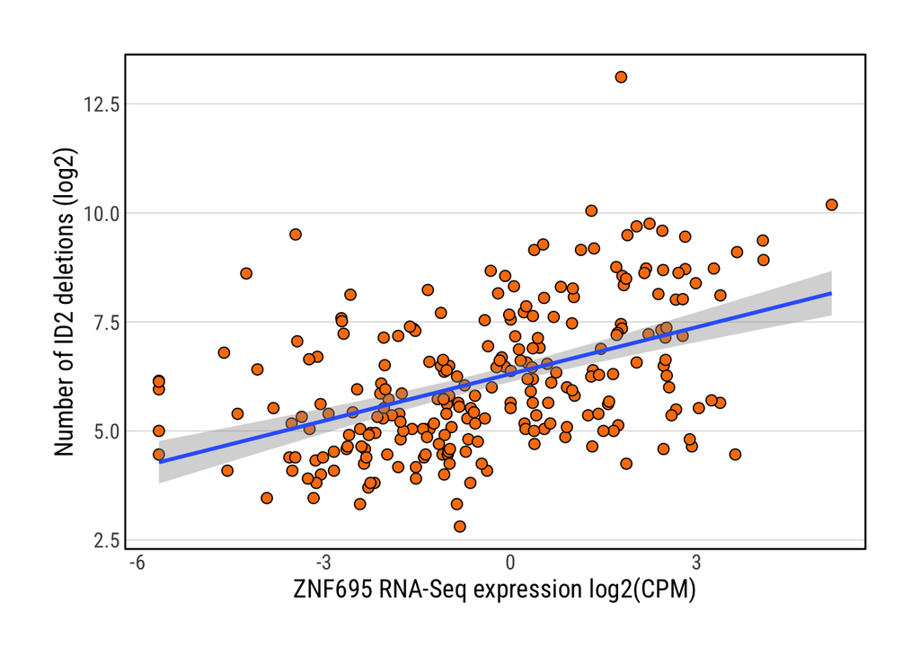

```r
#ggsave(filename = 'KZFPs_tumor_ID2_correlation.pdf',width = 7,height = 6,device = cairo_pdf)
#ggsave(filename = './output/KZFPs_tumor_ID2_correlation_mutivariable.pdf',width = 7,height = 6,device = cairo_pdf)

# Fig. 6d: individual correction ------------------------------------------
#Correlation between ZNF695 expression and deletions attributed to mutational signature ID2. Pearson correlation coefficients and corresponding p-values are displayed above the plot.

rdata1 %>%
  filter(RNAseq_Type == 'Tumor') %>%
  left_join(id2data %>% select(Tumor_Barcode,ID2)) %>%
  filter(Gene=='ZNF695') %>%
  #filter(Gene=='ZNF658B') %>%
  filter(ID2>0) %>%
  ggplot(aes(Exp,log2(ID2)))+
  geom_point(pch=21,stroke=0.5,fill=ncicolpal[2],size=2.5)+
  geom_smooth(method = 'lm')+
  theme_ipsum_rc(axis_title_just = 'm',axis_title_size = 14,grid = 'Y',strip_text_face = 'bold')+
  labs(y='Number of ID2 deletions (log2)',x='ZNF695 RNA-Seq expression log2(CPM)')+
  theme(panel.spacing = unit(0.2,'lines'),strip.text.x = element_text(face = 'plain',hjust = 0.5))+
  coord_cartesian(clip = 'off')+
  panel_border(color = 'black',linetype = 1,size=0.5)+
  guides(fill="none")
```

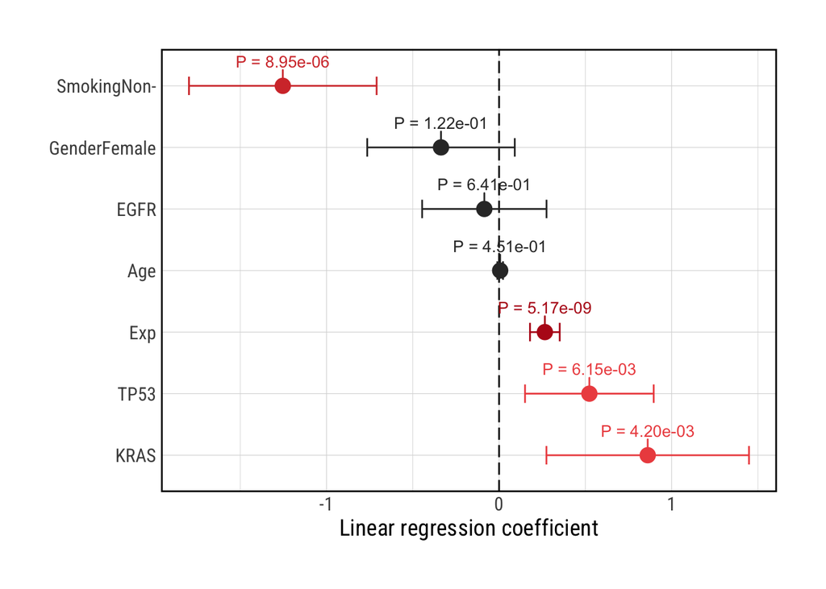

```r
#ggsave(filename = './output/KZFPs_tumor_ID2_correlation_example.pdf',width = 6,height = 5,device = cairo_pdf)

# adjust for the covariables
tmpresult <- rdata1 %>%
  filter(Gene=='ZNF695',RNAseq_Type == 'Tumor') %>%
  left_join(id2data %>% select(Tumor_Barcode,ID2)) %>%
  filter(ID2>0) %>%
  do(tidy(lm(log2(ID2) ~ Exp + Smoking + Age + Gender + TP53 + KRAS + EGFR, data=.,),conf.int = TRUE, conf.level = 0.95)) %>%
  filter(term!='(Intercept)') %>%
  ungroup() %>%
  arrange(desc(estimate)) %>%
  #mutate(term=str_remove(term,"EGFR")) %>%
  mutate(term=str_remove(term,"Smoker")) %>%
  mutate(term=str_remove(term,"Yes")) %>%
  mutate(label=paste0('P = ',scientific_format(digits = 3)(p.value)))

tmpresult %>%
  mutate(p.value2 = if_else(p.value>0.05,NA,-log10(p.value))) %>%
  #mutate(term=factor(term,levels=tmplevels,labels=tmplables)) %>%
  mutate(term=fct_inorder(term)) %>%
  ggplot(aes(estimate, term, xmin = conf.low, xmax = conf.high, height = 0,color=p.value2)) +
  geom_vline(xintercept = 0, lty = 5) +
  geom_errorbarh(height = .3)+
  geom_point(pch=19,size=4) +
  #scale_color_manual(values = c("FALSE"='black',"TRUE"='red'))+
  scale_color_gradient(low = "#EE5250FF",high = "#B71B1BFF",na.value = 'gray20')+
  ggrepel::geom_text_repel(aes(label=label),size=3.5,nudge_y = 0.4)+
  #facet_grid(~SP_Group_New)+
  theme_ipsum_rc(axis_title_just = 'm',axis_title_size = 14,grid_col = 'gray85')+
  theme(panel.spacing = unit(0.2,"cm"))+
  labs(x = "Linear regression coefficient", y = NULL)+
  guides(color="none")+
  scale_x_continuous(breaks = pretty_breaks())+
  panel_border(color = 'black',linetype = 1)
```

```r
#ggsave(filename = './output/KZFPs_tumor_ID2_correlation_example2.pdf',width = 6,height = 4,device = cairo_pdf)
```

## 6 Fig. 6e: Correlation between ZNF695 RNA-Seq expression and the median of DNA methylation levels across the genome locations of the CpG island on chr22q12.1.

Pearson correlation coefficients and corresponding p-values are displayed. # codes generated Fig. 6e can be found in the Fig5_LINE1_Methylation.R

## 7 Fig. 6f: Differentially expressed ZNF695 target genes identified between tumors with and without mutational signature ID2.

```r
ZNF695_targets <- unique(c("UBR5", "PPP2R1A", "PPP2R1B", "PSMB3", "PPP4C", "HECTD3", "USP9X", "BRE", "HECTD1", "TIMM50", "PPP2CB", "PSMC3", "PSMD3", "PSMD6", "PSMA6", "PSMA3", "PDCD5", "PSMD11", "DDI2", "PSMC1", "PSMC2", "PSMD7", "PSMC5", "DNAJA1", "PSMA2", "PSMC6","MEOX2", "TRIM28", "HECTD1", "H2BC21","MER4D", "MER4D1", "HAL1-2a_MD"))
length(ZNF695_targets)
```

```
## [1] 32
```

```r
load('./data/tresult_wilcox_ID2.RData',verbose = T)
```

```
## Loading objects:
##   tresult
##   fcdata
```

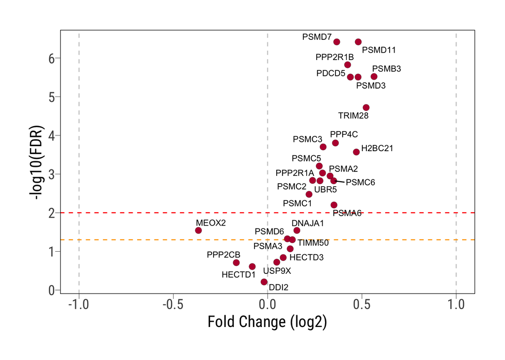

```r
tresult <- tresult %>%
  filter(Gene %in% ZNF695_targets) %>%
  mutate(FDR=p.adjust(p.value,method='BH'))


tresult %>%
  ggplot(aes(FC,-log10(FDR)))+
  geom_vline(xintercept = c(-1,0,1),linetype=2,col='#cccccc')+
  geom_hline(yintercept = -log10(0.01),linetype=2,col='red',size=0.5)+
  geom_hline(yintercept = -log10(0.05),linetype=2,col='orange',size=0.5)+
  geom_point(pch=21,col='black',size=3,stroke = 0.1,fill=ncicolpal[1])+
  scale_x_continuous(breaks = pretty_breaks())+
  scale_y_continuous(breaks = pretty_breaks(n=7))+
  #scale_fill_manual(values = c(ncicolpal[c(2,3,14)],'#cccccc'),na.value = '#cccccc')+
  ggrepel::geom_text_repel(data=tresult %>% arrange(FDR) %>% slice(1:50), aes(label=Gene),force = 10,size=3)+
  ggrepel::geom_text_repel(data=tresult %>% filter(Gene=='ZNF695'), aes(label=Gene),force = 10,size=4,col='red')+
  labs(x='Fold Change (log2)',y='-log10(FDR)')+
  guides(fill = guide_legend(override.aes = list(size=5)))+
  theme_ipsum_rc(base_size = 14,axis_title_just = 'm',axis_title_size = 16,grid=FALSE,ticks = T)+
  theme(legend.position = 'top')+
  panel_border(color = 'black',size = 0.5)
```

```r
#ggsave(filename = './output/tresult_wilcox_ID2_ZNF695_targets.pdf',width = 6,height = 6,device = cairo_pdf)

geneset1 <- tresult$Gene

# general target genes for kzfps
kzfps_targets <- readxl::read_xlsx('./data/ID2 Paper - KRAB-ZFP Target Genes Master List.xlsx',skip = 1,col_names = T) %>% pull(`Target Genes`)

length(kzfps_targets)
```

```
## [1] 72
```

```r
load('./data/tresult_wilcox_ID2.RData',verbose = T)
```

```
## Loading objects:
##   tresult
##   fcdata
```

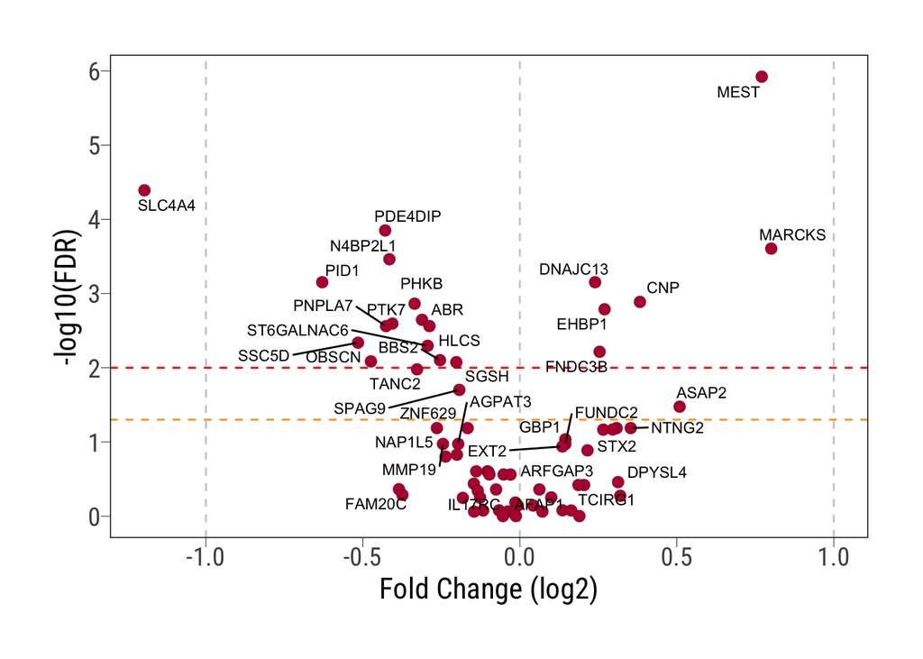

```r
tresult <- tresult %>%
  filter(Gene %in% kzfps_targets) %>%
  mutate(FDR=p.adjust(p.value,method='BH'))


tresult %>%
  ggplot(aes(FC,-log10(FDR)))+
  geom_vline(xintercept = c(-1,0,1),linetype=2,col='#cccccc')+
  geom_hline(yintercept = -log10(0.01),linetype=2,col='red',size=0.5)+
  geom_hline(yintercept = -log10(0.05),linetype=2,col='orange',size=0.5)+
  geom_point(pch=21,col='black',size=3,stroke = 0.1,fill=ncicolpal[1])+
  scale_x_continuous(breaks = pretty_breaks())+
  scale_y_continuous(breaks = pretty_breaks(n=7))+
  #scale_fill_manual(values = c(ncicolpal[c(2,3,14)],'#cccccc'),na.value = '#cccccc')+
  ggrepel::geom_text_repel(data=tresult %>% arrange(FDR) %>% slice(1:50), aes(label=Gene),force = 10,size=3)+
  ggrepel::geom_text_repel(data=tresult %>% filter(Gene=='ZNF695'), aes(label=Gene),force = 10,size=4,col='red')+
  labs(x='Fold Change (log2)',y='-log10(FDR)')+
  guides(fill = guide_legend(override.aes = list(size=5)))+
  theme_ipsum_rc(base_size = 14,axis_title_just = 'm',axis_title_size = 16,grid=FALSE,ticks = T)+
  theme(legend.position = 'top')+
  panel_border(color = 'black',size = 0.5)
```

```r
#ggsave(filename = './output/tresult_wilcox_ID2_KZFPs_targets.pdf',width = 6,height = 6,device = cairo_pdf)
```